# Assignment 6

JUFENG_YANG

2022-11-09

# Load Packages

```r
library(tidyverse)
```

# *1. Continuous random variables and limit laws*

## *1.1 Simulating data with the uniform distribution*

### **1.1 (Q.1)**

Show that for any pair of numbers a, b ∈ R with 0 ≤ a ≤ b ≤ 1, we have P(U ∈ [a, b]) = b − a.

$$for \qquad P_U =
\begin{cases}
1 \quad if \ x \in [a, b] \\[2ex]
0 \quad otherwise
\end{cases}$$
we can image the constant function $P_U = 1 \ (x \in [a, b])$. For the continues variable in [a, b], we have $\int_a^b 1$. The entire continues random variables in $R$ is 1. From this case, we have the variable in [a,b], we have probability $\frac{\int_a^b 1}{1} = b-a$.

### **1.1 (Q.2)**

Now, let’s consider the discrete random variable X (as defined above) and the case with α = β = 0.25. Generate a sequence of i.i.d. copies X1, X2, · · · , Xn of X as follows:

```r
set.seed(0)
n <- 1000
sample_X <- data.frame(U=runif(n)) %>%
mutate(X=case_when((0<=U)&(U<0.25)~3,
                   (0.25<=U)&(U<0.5)~10,
                   (0.5<=U)&(U<=1)~0)) %>%
pull(X)

sample_X %>% head(10)
```

```
##  [1]  0 10 10  0  0  3  0  0  0  0
```

In the code above, the function runif() can generate a random number in [0,1], so, the range [0, 0.25] in continue variable, the probabilaty is length of range / entire length (0.25 / 1) here, and same case, the length of range (0.25, 0.5] also is 0.25, the probility is 0.25/ 1. Thus $\alpha$ = 0.25, $\beta$ = 0.25, 1-$\alpha$ - $\beta$ = 0.5.

### **1.1 (Q.3)**

```r
sample_X_0310 <- function(a, b, n){
  set.seed(0)
  sample_x_0310 <- data.frame(U = runif(n)) %>%
    mutate(x = case_when((0<=U)&(U<a)~3,
                         (a<=U)&(U<b+a)~10,
                         (b+a<=U)&(U<=1)~0)) %>% pull(x)
  }
sample_copies <- sample_X_0310(0.25,0.25,100)
sample_copies
```

```
##   [1]  0 10 10  0  0  3  0  0  0  0  3  3  3  0 10  0 10  0  0 10  0  0  3  0  3
##  [26] 10 10  3 10  0 10 10  0 10  3  0  0  0  3  0 10  0  0  0  0  0  0  3 10  0
##  [51]  0 10  0 10  3  3  3 10  0  0 10  0 10 10 10  0 10 10  0  3  0 10  0 10 10
##  [76] 10  0  0 10  0  0 10  0 10 10  0  3  0  3  3  3  3  3  0  0  0  0 10 10  0
```

```r
#sample_copies %>% head(10)
```

### **1.1 (Q.4)**

Next take α = 1/2 and β = 1/10, and use your function sample_X_0310() to create a sample of size n = 10000 of the form X1, X2, · · · , Xn consisting of independent copies of X. What is the sample average of X1, X2, · · · , Xn? How does this compare with the theoretical value of E(X) (We have worked on the expression for this expectation in assignment 5 Section 2.1)? Then use your understanding of the law of large numbers to explain this behavior.

```r
sample_copies <- sample_X_0310(0.5, 0.1, 10000)
Mean_of_sample <- mean(sample_copies)
expectation <- 3*0.5 + 10*0.1 + 0
print("The mean of sample is:")
```

```
## [1] "The mean of sample is:"
```

```r
Mean_of_sample
```

```
## [1] 2.504
```

```r
print("The E(x) in theory: ")
```

```
## [1] "The E(x) in theory: "
```

```r
expectation
```

```
## [1] 2.5
```

### **1.1 (Q.5)**

Based on the sample generated from the last question, compute the sample variance of X1, X2, · · · , Xn and compare it with the population variance Var(X) (again, the expression of Var(X) has been derived in Assignment 5).

```r
Variance_of_sample <- var(sample_copies)
Var <- 9*0.5 + 100*0.1 + 0 - expectation^2
print("The variance of sample is:")
```

```
## [1] "The variance of sample is:"
```

```r
Variance_of_sample
```

```
## [1] 8.186803
```

```r
print("The E(x) in theory: ")
```

```
## [1] "The E(x) in theory: "
```

```r
Var
```

```
## [1] 8.25
```

### **1.1 (Q.6)**

Now take n = 100, α = 1/10 and vary β in increments of 0.01 from 0 to 9/10 (including 9/10). Create a data frame that has the following four columns. You can use the functions mutate, map, and map_dbl to help you. 1. The first column is called beta (contains different β values ranging from 0 to 9/10). 2. The second column is called sample_X including samples with the corresponding β. More specifically, for each value of β (in one of the rows), create a sample of X1, X2, · · · , Xn consisting of independent copies of X, by using your function sample_X_0310(). 3. The third column is called samplemean, which contains sample means of the samples. 4. The last column is called Expectation, which contains numerical values of the population mean E(X) (for the corresponding value of β in the same row).

```r
beta = seq(0, 0.9, 0.01)

beta_data <- data.frame(beta) %>% mutate(Samples = map(.x = beta, ~sample_X_0310(0.1, .x, 100))) %>% mutate(Sample_mean = map_dbl(Samples, mean)) %>% mutate(Expectation = map_dbl(.x = beta, ~(0.3 + .x*10)))
beta_data
```

```
##    beta
## 1  0.00
## 2  0.01
## 3  0.02
## 4  0.03
## 5  0.04
## 6  0.05
## 7  0.06
## 8  0.07
## 9  0.08
## 10 0.09
## 11 0.10
## 12 0.11
## 13 0.12
## 14 0.13
```

[output cut: 261 more lines]

### **1.1 (Q.7)**

Create a plot of the sample averages and E(X) as a function of β

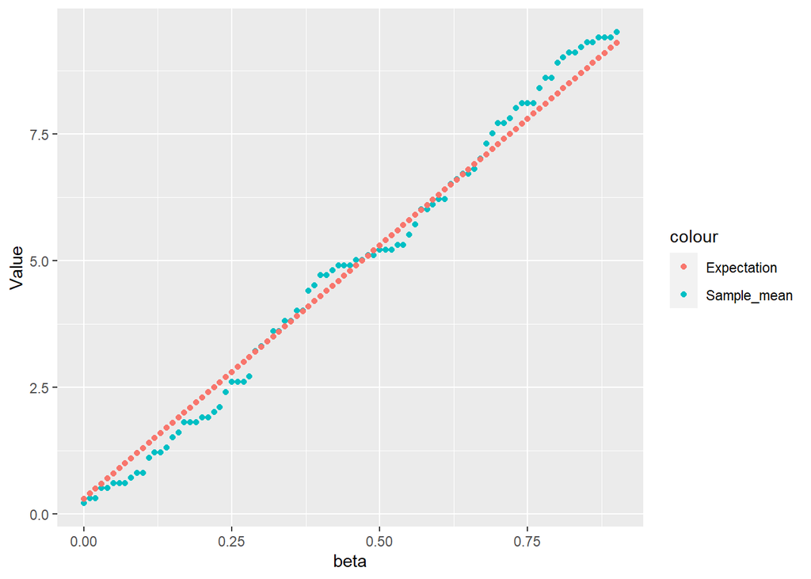

```r
beta_data %>% ggplot(aes(x=beta)) + labs(x="beta", y="Value") +
  geom_point(aes(y = Sample_mean, color="Sample_mean")) +
  geom_point(aes(y = Expectation, color="Expectation"))
```